# Example

The aim of this example is to provide an insight on the features of the subset of dashboard. Inferences drawn through the Bayesian Network are visualized on a map of India for a better understanding.

#### Set-up

We first install the customDashboard package through a local repository. For loading the package and subsequently running it, we execute the following code :

```
install.packages("path_to_customDashboard.tar", repos = NULL, type="source")
library(customDashboard)
customDashboard::IHDS_Subset()
```

The initial tab of the tool contains the Bayesian Network for the IHDS_Subset which can be represented in different formats through the drop down menu of “Visual Settings”. This tab also contains the “Infer Decisions” panel which will be used to display the inference learned through the network in the form of a barplot.

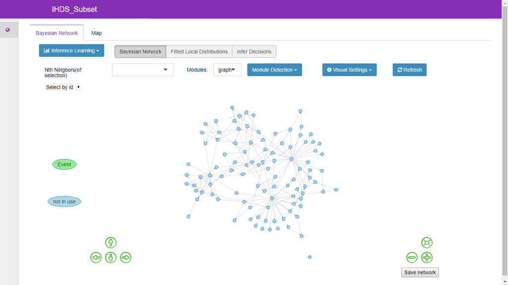

**Figure 1. Bayesian Network of IHDS_Subset**

There is another tab named “Map” which contains the political map of India along with a legend to mark the states.

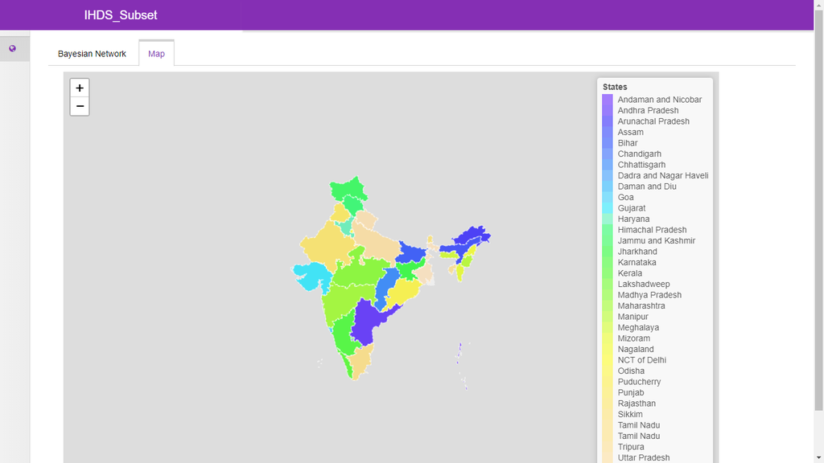

**Figure 2. Map of India**

There are two separate ways to proceed to drawing inferences. Each of which gives a map at a different level of accuracy (state or district) depending upon the Event Node. We first explore the results with the Event Node set to “State”.

#### Event – State

On the Bayesian Network tab panel, a drop down menu named “Inference Learning” is provided which is set-up as shown to infer a decision on the variable which gives the information about whether or not a hospital or clinic was visited for a minor illness.

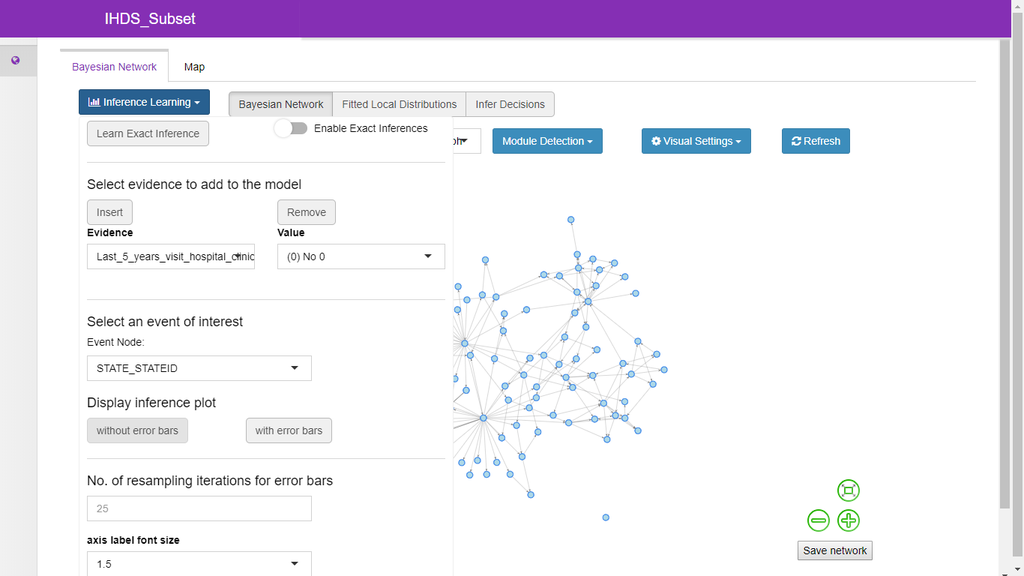

**Figure 3. Inference Learning Set-up**

The inference drawn is then displayed on the “Infer Decisions” panel and has been sorted in a descending order to present the probabilities of the states conditioned on the given variable.

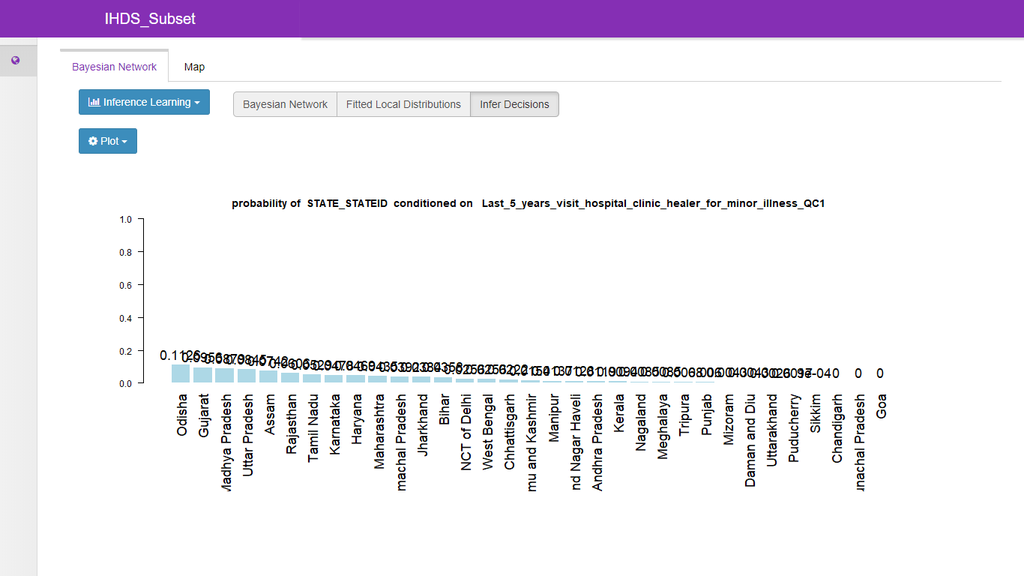

** Figure 4. Barplot result for all states in descending order**

These results are then also available on display in the “Map” tab in the form of a heatmap. A legend has been provided for the ease of the user along with the feature to hover over a state to get its exact probability value. The areas represented in grey colour either do not have their information in the IHDS data or equate to a zero probability.

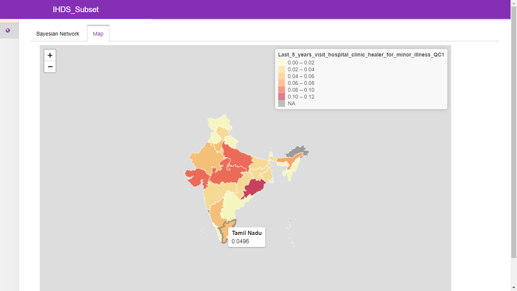

** Figure 5. Heatmap of India displaying results of all states**

While this inference was drawn without the error bars, there is an option provided to the user to also display the range of error that exists while drawing these inferences. The mean value from this range is selected to be displayed on the barplot and the map. There is another feature to limit the number of bars that are shown in the barplot to only assess the higher valued results.

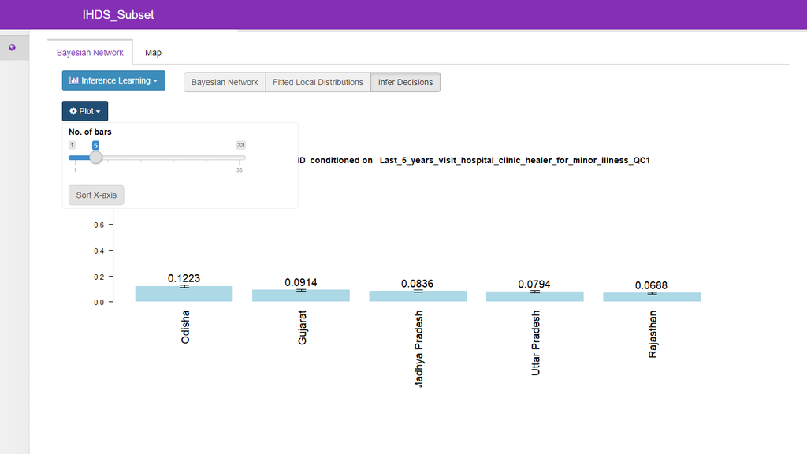

**Figure 6. Barplot with error bars displaying only the top 5 results in descending order**

When this result is displayed on the map, only the results shown in the barplot are present on the map. This way, the user can focus better on the data in concern. The other regions are greyed out.

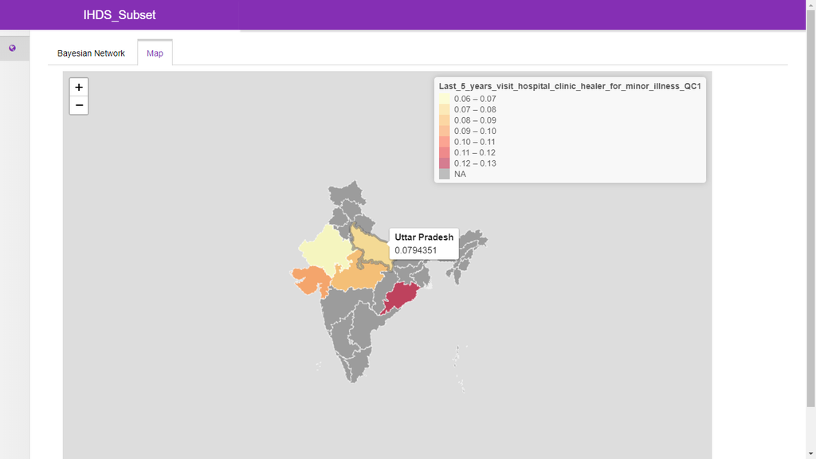

**Figure 7. Heatmap of India with only top 5 results**

#### Event – District

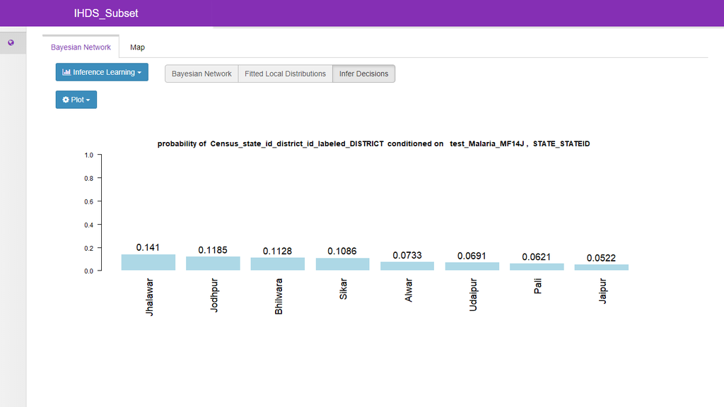

[figure not shown]